# Assignment 1 - Language Development in ASD - Power and simulations

## Welcome to the third exciting part of the Language Development in ASD exercise

In this part of the assignment, we try to figure out how a new study should be planned (i.e. how many participants?) in order to have enough power to replicate the findings (ensuring our sample size is adequate, our alpha at 0.05 and our beta at 0.8): 1- if we trust the estimates of the current study. Report the power analysis and comment on what you can (or cannot) use its estimates for. 2- if we are skeptical of the current study. Report the power analysis and comment on what you can (or cannot) use its estimates for. 3- if we only have access to 30 participants. Identify the power for each relevant effect and discuss whether it’s worth to run the study and why The list above is also what you should discuss in your code-less report.

## Learning objectives

- Learn how to calculate statistical power
- Critically appraise how to apply frequentist statistical power

### Exercise 1

How much power does your study have (if your model estimates are quite right)? - Load your dataset (both training and testing), fit your favorite model, assess power for your effects of interest (probably your interactions). - Report the power analysis and comment on what you can (or cannot) use its estimates for. - Test how many participants you would have to have to replicate the findings (assuming the findings are correct)

N.B. Remember that main effects are tricky once you have interactions in the model (same for 2-way interactions w 3-way interactions in the model). If you want to test the power of main effects, run a model excluding the interactions. N.B. Check this paper: https://besjournals.onlinelibrary.wiley.com/doi/full/10.1111/2041-210X.12504 You will be using: - powerSim() to calculate power - powerCurve() to estimate the needed number of participants - extend() to simulate more participants

```r
#ANDERS
#loading packages
pacman::p_load(tidyverse, readr,dplyr,stringr,lmerTest,Metrics,caret, lme4, reshape2, simr)
```

```r
#GUSTAV
#loading function from assignment A2_P2
CleanUpData <- function(demo,LU,token){

  Speech <- merge(LU, token) %>%
    rename(
      Subject = SUBJ,
      Visit = VISIT) %>%
    mutate(
      Visit = as.numeric(str_extract(Visit, "\\d")),
      Subject = gsub("\\.","", Subject)
      ) %>%
    dplyr::select(
      Subject, Visit, MOT_MLU, CHI_MLU, types_MOT, types_CHI, tokens_MOT, tokens_CHI
    )

  demo <- demo %>%
    rename(
      Subject = Child.ID) %>%
    dplyr::select(
      Subject, Visit, Ethnicity, Diagnosis, Gender, Age, ADOS, MullenRaw, ExpressiveLangRaw, Socialization
    ) %>%
    mutate(
      Subject = gsub("\\.","", Subject)
    )

  Data=merge(demo,Speech,all=T)

  Data1= Data %>%
     subset(Visit=="1") %>%
     dplyr::select(Subject, ADOS, ExpressiveLangRaw, MullenRaw, Socialization) %>%
     rename(Ados1 = ADOS,
            verbalIQ1 = ExpressiveLangRaw,
            nonVerbalIQ1 = MullenRaw,
            Socialization1 = Socialization)

  Data=merge(Data, Data1, all=T) %>%
    mutate(
      Subject = as.numeric(as.factor(as.character(Subject))),
      Visit = as.numeric(as.character(Visit)),
      Gender = recode(Gender,
         "1" = "M",
         "2" = "F"),
      Diagnosis = recode(Diagnosis,
         "A"  = "ASD",
         "B"  = "TD")
    )

  return(Data)
}
```

```r
#SIGRID
#loading df and filtering out NA's from CHI_MLU
data <- read_csv("data_clean.csv") %>%
  filter(
    is.na(CHI_MLU) == F, is.na(Age) == F) %>%
  rename('Subject' = 'Child.ID')


#loading test data and cleaning it with function from A2_P2
data_test <- CleanUpData(read_csv("Demo_test.csv"),
                         read_csv("LU_test.csv"),
                         read_csv("token_test.csv"))
```

```r
#ANDERS
#Fitting our favorite model. We have removed the growth curve because simr didnt like it.
#Also we changed "age" to "visit" because it is easier to interpret

#runnig model on full training data
m1 <- lme4::lmer(CHI_MLU ~ Diagnosis * Visit + (Visit|Subject), data)
summary(m1)
```

```
## Linear mixed model fit by REML ['lmerMod']
## Formula: CHI_MLU ~ Diagnosis * Visit + (Visit | Subject)
##    Data: data
##
## REML criterion at convergence: 560.7
##
## Scaled residuals:
##      Min       1Q   Median       3Q      Max
## -2.49319 -0.52447 -0.08099  0.44961  2.75428
##
## Random effects:
##  Groups   Name        Variance Std.Dev. Corr
##  Subject  (Intercept) 0.31488  0.5611
##           Visit       0.01209  0.1100   -0.20
##  Residual             0.15817  0.3977
## Number of obs: 346, groups:  Subject, 61
##
## Fixed effects:
##                   Estimate Std. Error t value
## (Intercept)        1.29508    0.12576  10.298
## DiagnosisTD       -0.19980    0.17366  -1.151
## Visit              0.10298    0.02772   3.715
## DiagnosisTD:Visit  0.24947    0.03814   6.541
##
## Correlation of Fixed Effects:
##             (Intr) DgnsTD Visit
## DiagnosisTD -0.724
## Visit       -0.456  0.330
## DgnssTD:Vst  0.332 -0.457 -0.727
```

```r
#running model on test_data
m1_test <- lme4::lmer(CHI_MLU ~ Diagnosis * Visit + (Visit|Subject), data_test)
```

```
## boundary (singular) fit: see ?isSingular
```

```r
summary(m1_test)
```

```
## Linear mixed model fit by REML ['lmerMod']
## Formula: CHI_MLU ~ Diagnosis * Visit + (Visit | Subject)
##    Data: data_test
##
## REML criterion at convergence: 49.2
##
## Scaled residuals:
##      Min       1Q   Median       3Q      Max
## -1.85256 -0.52728  0.00773  0.31936  2.16258
##
## Random effects:
##  Groups   Name        Variance Std.Dev. Corr
##  Subject  (Intercept) 0.07841  0.2800
##           Visit       0.01864  0.1365   1.00
##  Residual             0.11760  0.3429
## Number of obs: 35, groups:  Subject, 6
##
## Fixed effects:
##                   Estimate Std. Error t value
## (Intercept)        1.49044    0.25191   5.917
## DiagnosisTD       -0.36803    0.35152  -1.047
## Visit              0.10485    0.09256   1.133
## DiagnosisTD:Visit  0.23912    0.13047   1.833
##
## Correlation of Fixed Effects:
##             (Intr) DgnsTD Visit
## DiagnosisTD -0.717
## Visit        0.184 -0.132
## DgnssTD:Vst -0.130  0.200 -0.709
## convergence code: 0
## boundary (singular) fit: see ?isSingular
```

```r
#GUSTAV
#Accessing power for interaction
powerI <- powerSim(m1, simr::fixed('Diagnosis:Visit'), nsim = 50)
```

```r
powerI
```

```
## Power for predictor 'Diagnosis:Visit', (95% confidence interval):
##       100.0% (92.89, 100.0)
##
## Test: Kenward Roger (package pbkrtest)
##
## Based on 50 simulations, (24 warnings, 0 errors)
## alpha = 0.05, nrow = 346
##
## Time elapsed: 0 h 0 m 16 s
##
## nb: result might be an observed power calculation
```

```r
#power is 100% (93-100 confidence interval) with full dataset
```

```r
#SIGRID
#How many participants are needed for for finding an effect?

#full dataset
powerCurveI <-  powerCurve(m1, simr::fixed('Diagnosis:Visit'), along = 'Subject', nsim = 50)
```

```r
powerCurveI
```

```
## Power for predictor 'Diagnosis:Visit', (95% confidence interval),
## by largest value of Subject:
##       4:  0.00% ( 0.00,  7.11) - 17 rows
##      10: 52.00% (37.42, 66.34) - 50 rows
##      18: 88.00% (75.69, 95.47) - 91 rows
##      25: 98.00% (89.35, 99.95) - 125 rows
##      32: 98.00% (89.35, 99.95) - 166 rows
##      38: 100.0% (92.89, 100.0) - 202 rows
##      45: 100.0% (92.89, 100.0) - 240 rows
##      53: 100.0% (92.89, 100.0) - 272 rows
##      60: 100.0% (92.89, 100.0) - 313 rows
##      66: 100.0% (92.89, 100.0) - 346 rows
##
## Time elapsed: 0 h 1 m 52 s
```

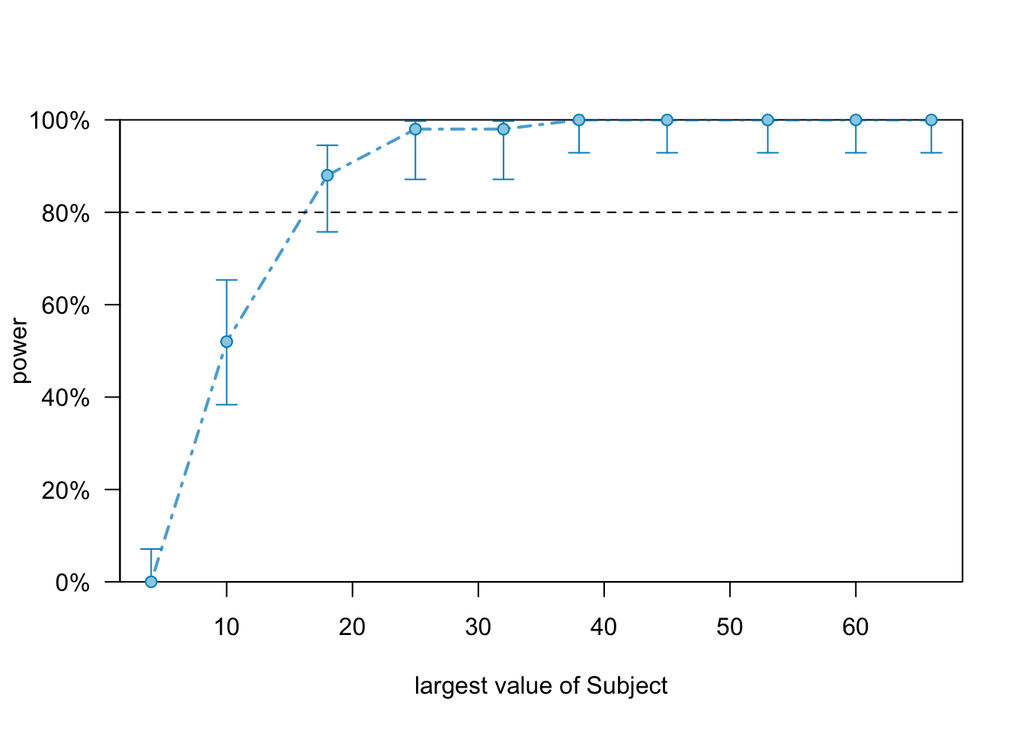

```r
plot(powerCurveI)
```